# Symulacje Monte Carlo i Bootstraping w środowisku R (234240-D)

Lab #1

Uladzislau Darhevich

2021-10-23

# 1. Wczytaj dane (3 szeregi czasowe)

Zbierzmy dane o cenach akcji dla niektórych tickerów (AMD, Intel, Qualcomm) za ostatnie 120 dni:

| ticker | src | download.status | total.obs |
| --- | --- | --- | --- |
| AMD | yahoo | OK | 84 |
| INTC | yahoo | OK | 84 |
| QCOM | yahoo | OK | 84 |

# 2. Stopa wzrotu dla skorygowanej ceny zamknięcia (Adjusted Closing Price)

Stopa wzrotu już jest podana w zbiorze danych za pomocą `BatchGetSymbols`, ale też obliczyłem ją samodzielnie

Table continues below

| price.open | price.high | price.low | price.close | volume | price.adjusted |
| --- | --- | --- | --- | --- | --- |
| 86.34 | 86.36 | 85.1 | 85.62 | 27804500 | 85.62 |
| 86.38 | 88 | 86.15 | 87.08 | 30262000 | 87.08 |
| 87.41 | 90.3 | 86.66 | 89.52 | 46181000 | 89.52 |
| 90.82 | 94.34 | 90.6 | 93.93 | 70721500 | 93.93 |
| 94.04 | 94.18 | 91.7 | 93.31 | 58059000 | 93.31 |
| 93.28 | 95.27 | 92.21 | 94.7 | 51316700 | 94.7 |
| 94.88 | 95.41 | 93.32 | 94.47 | 44930100 | 94.47 |
| 95.02 | 95.44 | 90.31 | 90.54 | 51498500 | 90.54 |
| 87.86 | 90.34 | 87.45 | 89.74 | 45673500 | 89.74 |
| 90.04 | 91.26 | 88.53 | 90.9 | 35278400 | 90.9 |

| ref.date | ticker | ret.adjusted.prices | ret.closing.prices | calc_RoR |
| --- | --- | --- | --- | --- |
| 2021-06-25 | AMD | NA | NA | NA |
| 2021-06-28 | AMD | 0.01705 | 0.01705 | 1.71 |
| 2021-06-29 | AMD | 0.02802 | 0.02802 | 2.8 |
| 2021-06-30 | AMD | 0.04926 | 0.04926 | 4.93 |
| 2021-07-01 | AMD | -0.006601 | -0.006601 | -0.66 |
| 2021-07-02 | AMD | 0.0149 | 0.0149 | 1.49 |
| 2021-07-06 | AMD | -0.002429 | -0.002429 | -0.24 |
| 2021-07-07 | AMD | -0.0416 | -0.0416 | -4.16 |
| 2021-07-08 | AMD | -0.008836 | -0.008836 | -0.88 |
| 2021-07-09 | AMD | 0.01293 | 0.01293 | 1.29 |

# 3. Oblicz średnią, kurtozę, skośność, odchylenie standardowe

Statystyki są podane niżej:

[output not shown]

# 4. Zbadaj czy zmienne mają rozkład normalny

p-value > 0,05 oznacza, że rozkład danych nie różni się znacząco od rozkładu normalnego. Innymi słowy, możemy przyjąć normalność

| ticker | statistic | p.value |
| --- | --- | --- |
| AMD | 0.9321 | 0.0002591 |
| INTC | 0.9558 | 0.005797 |
| QCOM | 0.9329 | 0.0002884 |

# 5. Zbadaj stacjonarność szeregu czasowego

- Test Ljung-Box sprawdza, czy istnieją istotne dowody na niezerowe korelacje, z hipotezą zerową o niezależności w danym szeregu czasowym (sygnał niestacjonarny będzie miał niską wartość p).
- Innym testem, który możemy przeprowadzić, jest test Dickey–Fullera (ADF), który ma sprawdzić, czy seria ma pierwiastek jednostkowy (seria z linią trendu będzie miała pierwiastek jednostkowy i spowoduje dużą wartość p).
- Na koniec możemy sprawdzić, czy szeregi czasowe są stacjonarne na poziomie lub trendu za pomocą testu Kwiatkowskiego-Phillipsa-Schmidta-Shina (KPSS). Tutaj przetestujemy hipotezę zerową stacjonarności trendu (niska wartość p wskaże sygnał, który nie jest stacjonarny trendu, ma pierwiastek jednostkowy)

**Szeregi czasowe nie są stacjonarne**

| ticker | Ljung-Box | Dickey-Fuller | KPSS |
| --- | --- | --- | --- |
| AMD | 0 | 0.5505 | 0.01 |
| INTC | 2.22e-16 | 0.1499 | 0.01 |
| QCOM | 0 | 0.6242 | 0.01 |

# 6. Narysuj wykres, histogram, wykres kwantyl-kwantyl

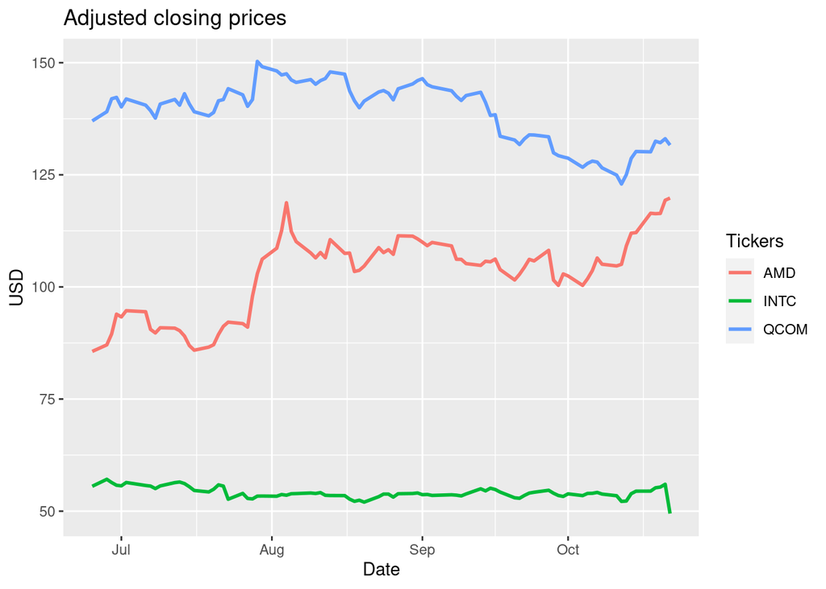

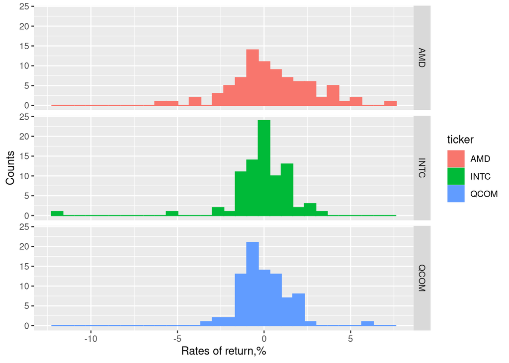

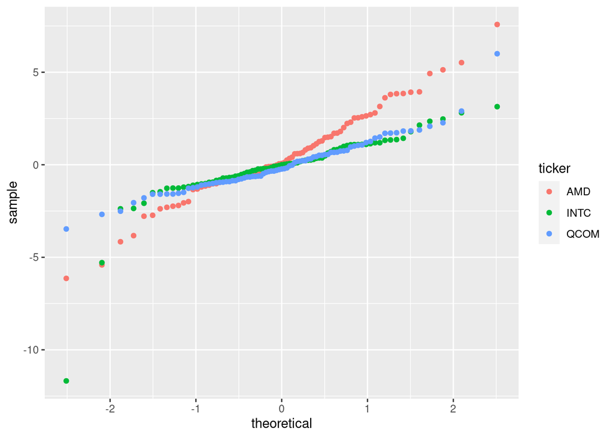

# 7. Oblicz obserwacje odstające powyżej 99 percentyla

powyżej 99 percentyla znajdują się następne obserwacje:

| price.adjusted | ref.date | ticker |
| --- | --- | --- |
| 119.8 | 2021-10-22 | AMD |
| 57.11 | 2021-06-28 | INTC |
| 150.3 | 2021-07-29 | QCOM |

# 8. Wyznacz korelacje między szeregami czasowymi

Korelacjia pomiędzy skorygowaną ceną zamknięcia dla AMD oraz Intel:

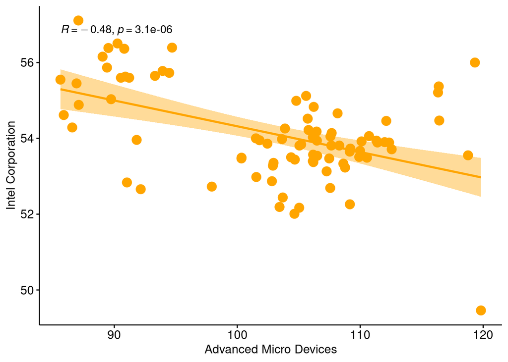

# 9. znajdź dopasowanie rozkładu t- Studenta do danych empirycznych

Wyznajmy dopasowanie rozkładu t- Studenta dla skorygowanej ceny zamknięcia dla firmy Qualcomm:

- **estimate**:

  | m | s | df |
  | --- | --- | --- |
  | 138.9 | 6.773 | 298175 |

- **sd**:

  | m | s | df |
  | --- | --- | --- |
  | 0.739 | 0.5226 | NA |

- **vcov**:

  |  | m | s | df |
  | --- | --- | --- | --- |
  | **m** | 0.5462 | -8.624e-06 | 4.312e-06 |
  | **s** | -8.624e-06 | 0.2731 | -0.1365 |
  | **df** | 4.312e-06 | -0.1365 | -70368744 |

- **loglik**: *-279.9*
- **n**: *84*